# Risk Factor Analysis

## Outcome Variable

**Outcome Variable:** ever_sstunted

## Predictor Variables

**Intervention Variable:** nchldlt5

**Adjustment Set:**

- arm
- W_mage
- meducyrs
- feducyrs
- hhwealth_quart
- hfoodsec
- W_mhtcm
- W_nrooms
- W_parity
- impfloor
- impsan
- safeh20
- delta_W_mage
- delta_meducyrs
- delta_feducyrs
- delta_hhwealth_quart
- delta_hfoodsec
- delta_W_mhtcm
- delta_W_nrooms
- delta_W_parity
- delta_impfloor
- delta_impsan
- delta_safeh20

## Stratifying Variables

The analysis was stratified on these variable(s):

- agecat
- studyid
- country

## Data Summary

| agecat | studyid | country | nchldlt5 | ever_sstunted | n_cell | n |
| --- | --- | --- | --- | --- | --- | --- |
| 0-24 months | ki1000108-IRC | INDIA | 1 | 0 | 64 | 410 |
| 0-24 months | ki1000108-IRC | INDIA | 1 | 1 | 25 | 410 |
| 0-24 months | ki1000108-IRC | INDIA | 2+ | 0 | 244 | 410 |
| 0-24 months | ki1000108-IRC | INDIA | 2+ | 1 | 77 | 410 |
| 0-24 months | ki1017093b-PROVIDE | BANGLADESH | 1 | 0 | 443 | 700 |
| 0-24 months | ki1017093b-PROVIDE | BANGLADESH | 1 | 1 | 69 | 700 |
| 0-24 months | ki1017093b-PROVIDE | BANGLADESH | 2+ | 0 | 163 | 700 |
| 0-24 months | ki1017093b-PROVIDE | BANGLADESH | 2+ | 1 | 25 | 700 |
| 0-24 months | ki1017093c-NIH-Crypto | BANGLADESH | 1 | 0 | 475 | 758 |
| 0-24 months | ki1017093c-NIH-Crypto | BANGLADESH | 1 | 1 | 66 | 758 |
| 0-24 months | ki1017093c-NIH-Crypto | BANGLADESH | 2+ | 0 | 184 | 758 |
| 0-24 months | ki1017093c-NIH-Crypto | BANGLADESH | 2+ | 1 | 33 | 758 |
| 0-24 months | ki1066203-TanzaniaChild2 | TANZANIA, UNITED REPUBLIC OF | 1 | 0 | 1479 | 2385 |
| 0-24 months | ki1066203-TanzaniaChild2 | TANZANIA, UNITED REPUBLIC OF | 1 | 1 | 158 | 2385 |
| 0-24 months | ki1066203-TanzaniaChild2 | TANZANIA, UNITED REPUBLIC OF | 2+ | 0 | 669 | 2385 |
| 0-24 months | ki1066203-TanzaniaChild2 | TANZANIA, UNITED REPUBLIC OF | 2+ | 1 | 79 | 2385 |
| 0-24 months | ki1112895-iLiNS-Zinc | BURKINA FASO | 1 | 0 | 977 | 3188 |
| 0-24 months | ki1112895-iLiNS-Zinc | BURKINA FASO | 1 | 1 | 96 | 3188 |
| 0-24 months | ki1112895-iLiNS-Zinc | BURKINA FASO | 2+ | 0 | 1879 | 3188 |
| 0-24 months | ki1112895-iLiNS-Zinc | BURKINA FASO | 2+ | 1 | 236 | 3188 |
| 0-24 months | ki1148112-LCNI-5 | MALAWI | 1 | 0 | 327 | 812 |
| 0-24 months | ki1148112-LCNI-5 | MALAWI | 1 | 1 | 64 | 812 |
| 0-24 months | ki1148112-LCNI-5 | MALAWI | 2+ | 0 | 315 | 812 |
| 0-24 months | ki1148112-LCNI-5 | MALAWI | 2+ | 1 | 106 | 812 |
| 0-24 months | kiGH5241-JiVitA-3 | BANGLADESH | 1 | 0 | 13954 | 27209 |
| 0-24 months | kiGH5241-JiVitA-3 | BANGLADESH | 1 | 1 | 3460 | 27209 |
| 0-24 months | kiGH5241-JiVitA-3 | BANGLADESH | 2+ | 0 | 8253 | 27209 |
| 0-24 months | kiGH5241-JiVitA-3 | BANGLADESH | 2+ | 1 | 1542 | 27209 |
| 0-6 months | ki1000108-IRC | INDIA | 1 | 0 | 68 | 410 |
| 0-6 months | ki1000108-IRC | INDIA | 1 | 1 | 21 | 410 |
| 0-6 months | ki1000108-IRC | INDIA | 2+ | 0 | 280 | 410 |
| 0-6 months | ki1000108-IRC | INDIA | 2+ | 1 | 41 | 410 |
| 0-6 months | ki1017093b-PROVIDE | BANGLADESH | 1 | 0 | 488 | 700 |
| 0-6 months | ki1017093b-PROVIDE | BANGLADESH | 1 | 1 | 24 | 700 |
| 0-6 months | ki1017093b-PROVIDE | BANGLADESH | 2+ | 0 | 181 | 700 |
| 0-6 months | ki1017093b-PROVIDE | BANGLADESH | 2+ | 1 | 7 | 700 |
| 0-6 months | ki1017093c-NIH-Crypto | BANGLADESH | 1 | 0 | 506 | 758 |
| 0-6 months | ki1017093c-NIH-Crypto | BANGLADESH | 1 | 1 | 35 | 758 |
| 0-6 months | ki1017093c-NIH-Crypto | BANGLADESH | 2+ | 0 | 205 | 758 |
| 0-6 months | ki1017093c-NIH-Crypto | BANGLADESH | 2+ | 1 | 12 | 758 |
| 0-6 months | ki1066203-TanzaniaChild2 | TANZANIA, UNITED REPUBLIC OF | 1 | 0 | 1564 | 2385 |
| 0-6 months | ki1066203-TanzaniaChild2 | TANZANIA, UNITED REPUBLIC OF | 1 | 1 | 73 | 2385 |
| 0-6 months | ki1066203-TanzaniaChild2 | TANZANIA, UNITED REPUBLIC OF | 2+ | 0 | 718 | 2385 |
| 0-6 months | ki1066203-TanzaniaChild2 | TANZANIA, UNITED REPUBLIC OF | 2+ | 1 | 30 | 2385 |
| 0-6 months | ki1148112-LCNI-5 | MALAWI | 1 | 0 | 111 | 267 |
| 0-6 months | ki1148112-LCNI-5 | MALAWI | 1 | 1 | 11 | 267 |
| 0-6 months | ki1148112-LCNI-5 | MALAWI | 2+ | 0 | 137 | 267 |
| 0-6 months | ki1148112-LCNI-5 | MALAWI | 2+ | 1 | 8 | 267 |
| 0-6 months | kiGH5241-JiVitA-3 | BANGLADESH | 1 | 0 | 14486 | 27143 |
| 0-6 months | kiGH5241-JiVitA-3 | BANGLADESH | 1 | 1 | 2877 | 27143 |
| 0-6 months | kiGH5241-JiVitA-3 | BANGLADESH | 2+ | 0 | 8674 | 27143 |
| 0-6 months | kiGH5241-JiVitA-3 | BANGLADESH | 2+ | 1 | 1106 | 27143 |

The following strata were considered:

- agecat: 0-24 months, studyid: ki1000108-IRC, country: INDIA
- agecat: 0-24 months, studyid: ki1017093b-PROVIDE, country: BANGLADESH
- agecat: 0-24 months, studyid: ki1017093c-NIH-Crypto, country: BANGLADESH
- agecat: 0-24 months, studyid: ki1066203-TanzaniaChild2, country: TANZANIA, UNITED REPUBLIC OF
- agecat: 0-24 months, studyid: ki1112895-iLiNS-Zinc, country: BURKINA FASO
- agecat: 0-24 months, studyid: ki1148112-LCNI-5, country: MALAWI
- agecat: 0-24 months, studyid: kiGH5241-JiVitA-3, country: BANGLADESH
- agecat: 0-6 months, studyid: ki1000108-IRC, country: INDIA
- agecat: 0-6 months, studyid: ki1017093b-PROVIDE, country: BANGLADESH
- agecat: 0-6 months, studyid: ki1017093c-NIH-Crypto, country: BANGLADESH
- agecat: 0-6 months, studyid: ki1066203-TanzaniaChild2, country: TANZANIA, UNITED REPUBLIC OF
- agecat: 0-6 months, studyid: ki1148112-LCNI-5, country: MALAWI
- agecat: 0-6 months, studyid: kiGH5241-JiVitA-3, country: BANGLADESH

## Methods Detail

We’re interested in the causal parameters $E[Y_a]$ for all values of $a \in \mathcal{A}$. These parameters represent the mean outcome if, possibly contrary to fact, we intervened to set all units to have $A=a$. Under the randomization and positivity assumptions, these are identified by the statistical parameters $\psi_a=E_W[E_{Y|A,W}(Y|A=a,W)]$. In addition, we’re interested in the mean of $Y$, $E[Y]$ under no intervention (the observed mean). We will estimate these parameters by using SuperLearner to fit the relevant likelihood factors – $E_{Y|A,W}(Y|A=a,W)$ and $p(A=a|W)$, and then updating our likelihood fit using a joint TMLE.

For unadjusted analyses ($W=\{\}$), initial likelihoods were estimated using Lrnr_glm to estimate the simple $E(Y|A)$ and Lrnr_mean to estimate $p(A)$. For adjusted analyses, a small library containing Lrnr_glmnet, Lrnr_xgboost, and Lrnr_mean was used.

Having estimated these parameters, we will then use the delta method to estimate relative risks and attributable risks relative to a prespecified baseline level of $A$.

# Results Detail

## Results Plots

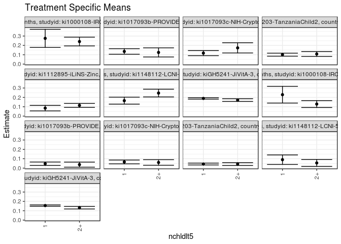

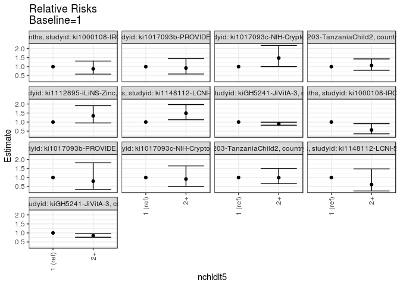

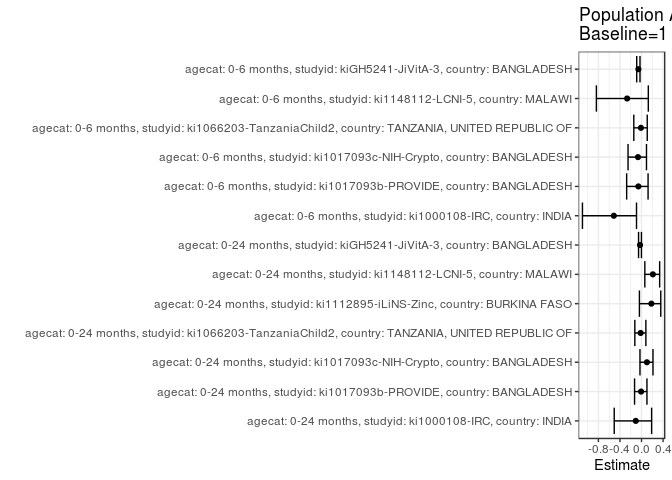

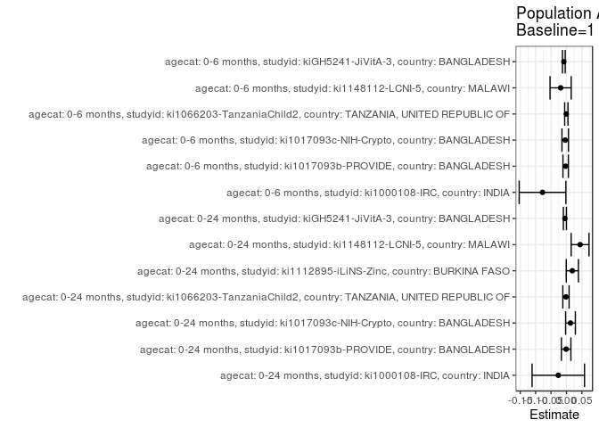

## Results Table

### Parameter: TSM

| agecat | studyid | country | intervention_level | baseline_level | estimate | ci_lower | ci_upper |
| --- | --- | --- | --- | --- | --- | --- | --- |
| 0-24 months | ki1000108-IRC | INDIA | 1 | NA | 0.2752131 | 0.1785582 | 0.3718681 |
| 0-24 months | ki1000108-IRC | INDIA | 2+ | NA | 0.2409814 | 0.1940530 | 0.2879098 |
| 0-24 months | ki1017093b-PROVIDE | BANGLADESH | 1 | NA | 0.1352915 | 0.1057899 | 0.1647930 |
| 0-24 months | ki1017093b-PROVIDE | BANGLADESH | 2+ | NA | 0.1248863 | 0.0761569 | 0.1736157 |
| 0-24 months | ki1017093c-NIH-Crypto | BANGLADESH | 1 | NA | 0.1175166 | 0.0903072 | 0.1447260 |
| 0-24 months | ki1017093c-NIH-Crypto | BANGLADESH | 2+ | NA | 0.1734456 | 0.1188470 | 0.2280441 |
| 0-24 months | ki1066203-TanzaniaChild2 | TANZANIA, UNITED REPUBLIC OF | 1 | NA | 0.1009922 | 0.0849145 | 0.1170699 |
| 0-24 months | ki1066203-TanzaniaChild2 | TANZANIA, UNITED REPUBLIC OF | 2+ | NA | 0.1079438 | 0.0819592 | 0.1339284 |
| 0-24 months | ki1112895-iLiNS-Zinc | BURKINA FASO | 1 | NA | 0.0850820 | 0.0556745 | 0.1144895 |
| 0-24 months | ki1112895-iLiNS-Zinc | BURKINA FASO | 2+ | NA | 0.1145740 | 0.0933798 | 0.1357682 |
| 0-24 months | ki1148112-LCNI-5 | MALAWI | 1 | NA | 0.1651870 | 0.1281945 | 0.2021794 |
| 0-24 months | ki1148112-LCNI-5 | MALAWI | 2+ | NA | 0.2462310 | 0.2049714 | 0.2874907 |
| 0-24 months | kiGH5241-JiVitA-3 | BANGLADESH | 1 | NA | 0.1889106 | 0.1813799 | 0.1964413 |
| 0-24 months | kiGH5241-JiVitA-3 | BANGLADESH | 2+ | NA | 0.1712148 | 0.1570400 | 0.1853896 |
| 0-6 months | ki1000108-IRC | INDIA | 1 | NA | 0.2288479 | 0.1397099 | 0.3179860 |
| 0-6 months | ki1000108-IRC | INDIA | 2+ | NA | 0.1287830 | 0.0920834 | 0.1654826 |
| 0-6 months | ki1017093b-PROVIDE | BANGLADESH | 1 | NA | 0.0468750 | 0.0285532 | 0.0651968 |
| 0-6 months | ki1017093b-PROVIDE | BANGLADESH | 2+ | NA | 0.0372340 | 0.0101502 | 0.0643179 |
| 0-6 months | ki1017093c-NIH-Crypto | BANGLADESH | 1 | NA | 0.0660496 | 0.0453317 | 0.0867674 |
| 0-6 months | ki1017093c-NIH-Crypto | BANGLADESH | 2+ | NA | 0.0602981 | 0.0303659 | 0.0902304 |
| 0-6 months | ki1066203-TanzaniaChild2 | TANZANIA, UNITED REPUBLIC OF | 1 | NA | 0.0436472 | 0.0337747 | 0.0535197 |
| 0-6 months | ki1066203-TanzaniaChild2 | TANZANIA, UNITED REPUBLIC OF | 2+ | NA | 0.0432374 | 0.0282705 | 0.0582044 |
| 0-6 months | ki1148112-LCNI-5 | MALAWI | 1 | NA | 0.0901639 | 0.0392448 | 0.1410831 |
| 0-6 months | ki1148112-LCNI-5 | MALAWI | 2+ | NA | 0.0551724 | 0.0179404 | 0.0924044 |
| 0-6 months | kiGH5241-JiVitA-3 | BANGLADESH | 1 | NA | 0.1552790 | 0.1482556 | 0.1623023 |
| 0-6 months | kiGH5241-JiVitA-3 | BANGLADESH | 2+ | NA | 0.1324722 | 0.1189100 | 0.1460345 |

### Parameter: E(Y)

| agecat | studyid | country | intervention_level | baseline_level | estimate | ci_lower | ci_upper |
| --- | --- | --- | --- | --- | --- | --- | --- |
| 0-24 months | ki1000108-IRC | INDIA | NA | NA | 0.2487805 | 0.2068840 | 0.2906770 |
| 0-24 months | ki1017093b-PROVIDE | BANGLADESH | NA | NA | 0.1342857 | 0.1090095 | 0.1595619 |
| 0-24 months | ki1017093c-NIH-Crypto | BANGLADESH | NA | NA | 0.1306069 | 0.1066024 | 0.1546113 |
| 0-24 months | ki1066203-TanzaniaChild2 | TANZANIA, UNITED REPUBLIC OF | NA | NA | 0.0993711 | 0.0873623 | 0.1113798 |
| 0-24 months | ki1112895-iLiNS-Zinc | BURKINA FASO | NA | NA | 0.1041405 | 0.0842158 | 0.1240653 |
| 0-24 months | ki1148112-LCNI-5 | MALAWI | NA | NA | 0.2093596 | 0.1813586 | 0.2373606 |
| 0-24 months | kiGH5241-JiVitA-3 | BANGLADESH | NA | NA | 0.1838362 | 0.1782586 | 0.1894138 |
| 0-6 months | ki1000108-IRC | INDIA | NA | NA | 0.1512195 | 0.1164988 | 0.1859402 |
| 0-6 months | ki1017093b-PROVIDE | BANGLADESH | NA | NA | 0.0442857 | 0.0290345 | 0.0595370 |
| 0-6 months | ki1017093c-NIH-Crypto | BANGLADESH | NA | NA | 0.0620053 | 0.0448256 | 0.0791849 |
| 0-6 months | ki1066203-TanzaniaChild2 | TANZANIA, UNITED REPUBLIC OF | NA | NA | 0.0431866 | 0.0350267 | 0.0513464 |
| 0-6 months | ki1148112-LCNI-5 | MALAWI | NA | NA | 0.0711610 | 0.0402653 | 0.1020568 |
| 0-6 months | kiGH5241-JiVitA-3 | BANGLADESH | NA | NA | 0.1467413 | 0.1417260 | 0.1517566 |

### Parameter: RR

| agecat | studyid | country | intervention_level | baseline_level | estimate | ci_lower | ci_upper |
| --- | --- | --- | --- | --- | --- | --- | --- |
| 0-24 months | ki1000108-IRC | INDIA | 1 | 1 | 1.0000000 | 1.0000000 | 1.0000000 |
| 0-24 months | ki1000108-IRC | INDIA | 2+ | 1 | 0.8756173 | 0.5860954 | 1.3081585 |
| 0-24 months | ki1017093b-PROVIDE | BANGLADESH | 1 | 1 | 1.0000000 | 1.0000000 | 1.0000000 |
| 0-24 months | ki1017093b-PROVIDE | BANGLADESH | 2+ | 1 | 0.9230908 | 0.5906533 | 1.4426341 |
| 0-24 months | ki1017093c-NIH-Crypto | BANGLADESH | 1 | 1 | 1.0000000 | 1.0000000 | 1.0000000 |
| 0-24 months | ki1017093c-NIH-Crypto | BANGLADESH | 2+ | 1 | 1.4759242 | 1.0013918 | 2.1753246 |
| 0-24 months | ki1066203-TanzaniaChild2 | TANZANIA, UNITED REPUBLIC OF | 1 | 1 | 1.0000000 | 1.0000000 | 1.0000000 |
| 0-24 months | ki1066203-TanzaniaChild2 | TANZANIA, UNITED REPUBLIC OF | 2+ | 1 | 1.0688327 | 0.8008255 | 1.4265322 |
| 0-24 months | ki1112895-iLiNS-Zinc | BURKINA FASO | 1 | 1 | 1.0000000 | 1.0000000 | 1.0000000 |
| 0-24 months | ki1112895-iLiNS-Zinc | BURKINA FASO | 2+ | 1 | 1.3466306 | 0.9511968 | 1.9064552 |
| 0-24 months | ki1148112-LCNI-5 | MALAWI | 1 | 1 | 1.0000000 | 1.0000000 | 1.0000000 |
| 0-24 months | ki1148112-LCNI-5 | MALAWI | 2+ | 1 | 1.4906202 | 1.1297189 | 1.9668154 |
| 0-24 months | kiGH5241-JiVitA-3 | BANGLADESH | 1 | 1 | 1.0000000 | 1.0000000 | 1.0000000 |
| 0-24 months | kiGH5241-JiVitA-3 | BANGLADESH | 2+ | 1 | 0.9063273 | 0.8278484 | 0.9922458 |
| 0-6 months | ki1000108-IRC | INDIA | 1 | 1 | 1.0000000 | 1.0000000 | 1.0000000 |
| 0-6 months | ki1000108-IRC | INDIA | 2+ | 1 | 0.5627449 | 0.3476473 | 0.9109284 |
| 0-6 months | ki1017093b-PROVIDE | BANGLADESH | 1 | 1 | 1.0000000 | 1.0000000 | 1.0000000 |
| 0-6 months | ki1017093b-PROVIDE | BANGLADESH | 2+ | 1 | 0.7943262 | 0.3478373 | 1.8139348 |
| 0-6 months | ki1017093c-NIH-Crypto | BANGLADESH | 1 | 1 | 1.0000000 | 1.0000000 | 1.0000000 |
| 0-6 months | ki1017093c-NIH-Crypto | BANGLADESH | 2+ | 1 | 0.9129224 | 0.5076968 | 1.6415849 |
| 0-6 months | ki1066203-TanzaniaChild2 | TANZANIA, UNITED REPUBLIC OF | 1 | 1 | 1.0000000 | 1.0000000 | 1.0000000 |
| 0-6 months | ki1066203-TanzaniaChild2 | TANZANIA, UNITED REPUBLIC OF | 2+ | 1 | 0.9906113 | 0.6552059 | 1.4977135 |
| 0-6 months | ki1148112-LCNI-5 | MALAWI | 1 | 1 | 1.0000000 | 1.0000000 | 1.0000000 |
| 0-6 months | ki1148112-LCNI-5 | MALAWI | 2+ | 1 | 0.6119122 | 0.2538214 | 1.4751968 |
| 0-6 months | kiGH5241-JiVitA-3 | BANGLADESH | 1 | 1 | 1.0000000 | 1.0000000 | 1.0000000 |
| 0-6 months | kiGH5241-JiVitA-3 | BANGLADESH | 2+ | 1 | 0.8531243 | 0.7623645 | 0.9546891 |

### Parameter: PAR

| agecat | studyid | country | intervention_level | baseline_level | estimate | ci_lower | ci_upper |
| --- | --- | --- | --- | --- | --- | --- | --- |
| 0-24 months | ki1000108-IRC | INDIA | 1 | NA | -0.0264327 | -0.1114913 | 0.0586260 |
| 0-24 months | ki1017093b-PROVIDE | BANGLADESH | 1 | NA | -0.0010058 | -0.0164075 | 0.0143960 |
| 0-24 months | ki1017093c-NIH-Crypto | BANGLADESH | 1 | NA | 0.0130903 | -0.0027231 | 0.0289037 |
| 0-24 months | ki1066203-TanzaniaChild2 | TANZANIA, UNITED REPUBLIC OF | 1 | NA | -0.0016212 | -0.0117891 | 0.0085468 |
| 0-24 months | ki1112895-iLiNS-Zinc | BURKINA FASO | 1 | NA | 0.0190585 | -0.0006982 | 0.0388153 |
| 0-24 months | ki1148112-LCNI-5 | MALAWI | 1 | NA | 0.0441726 | 0.0152291 | 0.0731162 |
| 0-24 months | kiGH5241-JiVitA-3 | BANGLADESH | 1 | NA | -0.0050744 | -0.0100087 | -0.0001400 |
| 0-6 months | ki1000108-IRC | INDIA | 1 | NA | -0.0776284 | -0.1534281 | -0.0018287 |
| 0-6 months | ki1017093b-PROVIDE | BANGLADESH | 1 | NA | -0.0025893 | -0.0113770 | 0.0061984 |
| 0-6 months | ki1017093c-NIH-Crypto | BANGLADESH | 1 | NA | -0.0040443 | -0.0146204 | 0.0065318 |
| 0-6 months | ki1066203-TanzaniaChild2 | TANZANIA, UNITED REPUBLIC OF | 1 | NA | -0.0004606 | -0.0058301 | 0.0049088 |
| 0-6 months | ki1148112-LCNI-5 | MALAWI | 1 | NA | -0.0190029 | -0.0533233 | 0.0153176 |
| 0-6 months | kiGH5241-JiVitA-3 | BANGLADESH | 1 | NA | -0.0085376 | -0.0130075 | -0.0040677 |

### Parameter: PAF

| agecat | studyid | country | intervention_level | baseline_level | estimate | ci_lower | ci_upper |
| --- | --- | --- | --- | --- | --- | --- | --- |
| 0-24 months | ki1000108-IRC | INDIA | 1 | NA | -0.1062489 | -0.5063113 | 0.1875606 |
| 0-24 months | ki1017093b-PROVIDE | BANGLADESH | 1 | NA | -0.0074898 | -0.1289883 | 0.1009334 |
| 0-24 months | ki1017093c-NIH-Crypto | BANGLADESH | 1 | NA | 0.1002267 | -0.0285896 | 0.2129105 |
| 0-24 months | ki1066203-TanzaniaChild2 | TANZANIA, UNITED REPUBLIC OF | 1 | NA | -0.0163143 | -0.1238894 | 0.0809641 |
| 0-24 months | ki1112895-iLiNS-Zinc | BURKINA FASO | 1 | NA | 0.1830079 | -0.0388518 | 0.3574866 |
| 0-24 months | ki1148112-LCNI-5 | MALAWI | 1 | NA | 0.2109892 | 0.0617222 | 0.3365100 |
| 0-24 months | kiGH5241-JiVitA-3 | BANGLADESH | 1 | NA | -0.0276028 | -0.0547913 | -0.0011151 |
| 0-6 months | ki1000108-IRC | INDIA | 1 | NA | -0.5133492 | -1.0958157 | -0.0927611 |
| 0-6 months | ki1017093b-PROVIDE | BANGLADESH | 1 | NA | -0.0584677 | -0.2756059 | 0.1217084 |
| 0-6 months | ki1017093c-NIH-Crypto | BANGLADESH | 1 | NA | -0.0652251 | -0.2500336 | 0.0922608 |
| 0-6 months | ki1066203-TanzaniaChild2 | TANZANIA, UNITED REPUBLIC OF | 1 | NA | -0.0106660 | -0.1429330 | 0.1062944 |
| 0-6 months | ki1148112-LCNI-5 | MALAWI | 1 | NA | -0.2670406 | -0.8374155 | 0.1262772 |
| 0-6 months | kiGH5241-JiVitA-3 | BANGLADESH | 1 | NA | -0.0581814 | -0.0889602 | -0.0282726 |